# Marketing A/B Analysis

2026-06-21

# Create a 10% sample dataset

The following code shows how `marketing_AB_mini.csv` was created from the original dataset. It is shown for documentation and is not rerun as part of this report.

```r
marketing_AB <- read.csv("marketing_AB.csv")

set.seed(42)

n_sample <- floor(0.10 * nrow(marketing_AB))

marketing_AB_mini <- marketing_AB[
  sample(1:nrow(marketing_AB), size = n_sample, replace = FALSE),
]

write.csv(
  marketing_AB_mini,
  "marketing_AB_mini.csv",
  row.names = FALSE
)
```

# 1. Load the data

```r
marketing <- read_csv("marketing_AB_mini.csv")

dim(marketing)
```

```
## [1] 58810     6
```

```r
head(marketing)
```

```
## # A tibble: 6 × 6
##   `user id` `test group` converted `total ads` `most ads day` `most ads hour`
##       <dbl> <chr>        <lgl>           <dbl> <chr>                    <dbl>
## 1   1317070 ad           FALSE              36 Sunday                      14
## 2    903624 psa          FALSE              16 Tuesday                     16
## 3   1242031 ad           FALSE               7 Saturday                    20
## 4   1379296 ad           FALSE              13 Thursday                     0
## 5   1162733 ad           FALSE              24 Sunday                      15
## 6   1150469 ad           FALSE               2 Tuesday                     12
```

```r
summary(marketing)
```

```
##     user id         test group        converted         total ads
##  Min.   : 900021   Length:58810       Mode :logical   Min.   :   1.00
##  1st Qu.:1144910   Class :character   FALSE:57320     1st Qu.:   4.00
##  Median :1315774   Mode  :character   TRUE :1490      Median :  13.00
##  Mean   :1311449                                      Mean   :  24.58
##  3rd Qu.:1483677                                      3rd Qu.:  27.00
##  Max.   :1654466                                      Max.   :1391.00
##  most ads day       most ads hour
##  Length:58810       Min.   : 0.0
##  Class :character   1st Qu.:11.0
##  Mode  :character   Median :14.0
##                     Mean   :14.5
##                     3rd Qu.:18.0
##                     Max.   :23.0
```

```r
range(marketing$`most ads hour`, na.rm = TRUE)
```

```
## [1]  0 23
```

```r
sort(unique(marketing$`most ads hour`))
```

```
##  [1]  0  1  2  3  4  5  6  7  8  9 10 11 12 13 14 15 16 17 18 19 20 21 22 23
```

The dataset has 58810 rows and 6 columns.

# 2. IQR outlier check

The IQR rule marks values below Q1 - 1.5 x IQR or above Q3 + 1.5 x IQR as outliers.

```r
numeric_names <- c("total ads", "most ads hour")

outlier_results <- data.frame()

for (name in numeric_names) {
  x <- marketing[[name]]
  q1 <- quantile(x, 0.25, na.rm = TRUE)
  q3 <- quantile(x, 0.75, na.rm = TRUE)
  iqr <- q3 - q1
  lower <- q1 - 1.5 * iqr
  upper <- q3 + 1.5 * iqr
  count <- sum(x < lower | x > upper, na.rm = TRUE)

  outlier_results <- rbind(
    outlier_results,
    data.frame(
      Variable = name,
      Q1 = q1,
      Q3 = q3,
      IQR = iqr,
      Lower_Bound = lower,
      Upper_Bound = upper,
      Outlier_Count = count,
      Contains_Outliers = ifelse(count > 0, "Yes", "No")
    )
  )
}

rownames(outlier_results) <- NULL
print(outlier_results)
```

```
##        Variable Q1 Q3 IQR Lower_Bound Upper_Bound Outlier_Count
## 1     total ads  4 27  23       -30.5        61.5          5152
## 2 most ads hour 11 18   7         0.5        28.5           564
##   Contains_Outliers
## 1               Yes
## 2               Yes
```

`user id` is excluded because it is an identifier rather than a meaningful variable for outlier analysis.

# 3. Visualizations

## Numerical distributions

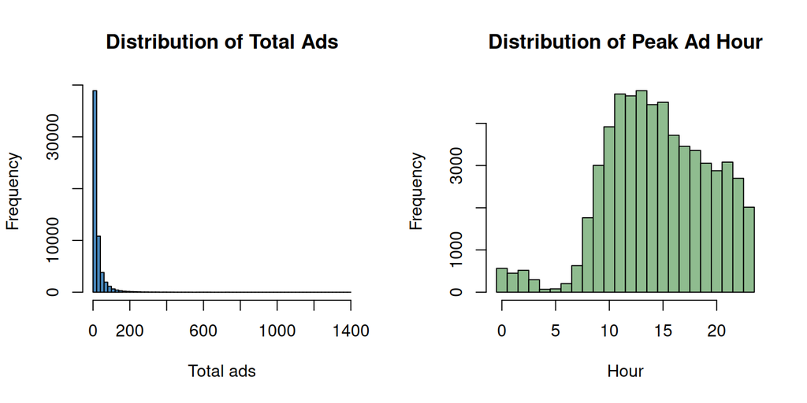

```r
par(mfrow = c(1, 2))

hist(marketing$`total ads`, breaks = 50, col = "steelblue",
     main = "Distribution of Total Ads", xlab = "Total ads")

hist(marketing$`most ads hour`, breaks = seq(-0.5, 23.5, 1),
     col = "darkseagreen", main = "Distribution of Peak Ad Hour",
     xlab = "Hour")
```

```r
par(mfrow = c(1, 1))
```

## Boxplot for outliers

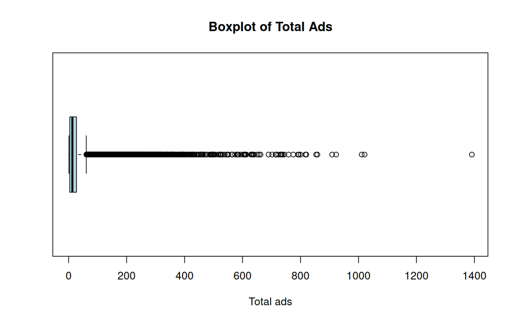

```r
boxplot(marketing$`total ads`, horizontal = TRUE, col = "lightblue",
        main = "Boxplot of Total Ads", xlab = "Total ads")
```

## Categorical variables

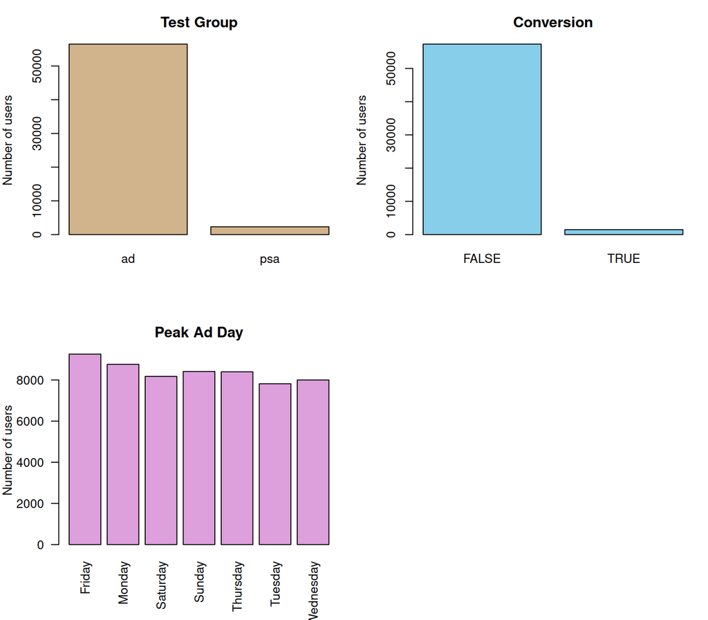

```r
par(mfrow = c(2, 2), mar = c(5, 4, 3, 1))

barplot(table(marketing$`test group`), col = "tan",
        main = "Test Group", ylab = "Number of users")

barplot(table(marketing$converted), col = "skyblue",
        main = "Conversion", ylab = "Number of users")

barplot(table(marketing$`most ads day`), col = "plum",
        main = "Peak Ad Day", ylab = "Number of users", las = 2)

par(mfrow = c(1, 1))
```

## Advertising exposure and conversion

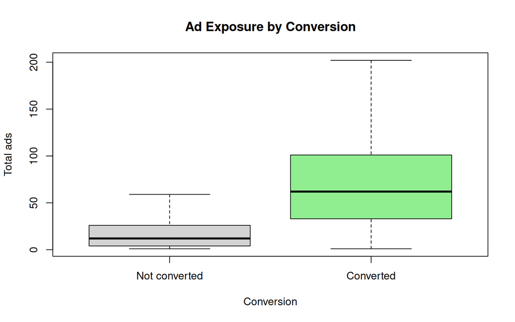

```r
boxplot(`total ads` ~ converted, data = marketing,
        names = c("Not converted", "Converted"),
        col = c("lightgray", "lightgreen"),
        main = "Ad Exposure by Conversion",
        xlab = "Conversion", ylab = "Total ads",
        outline = FALSE)
```

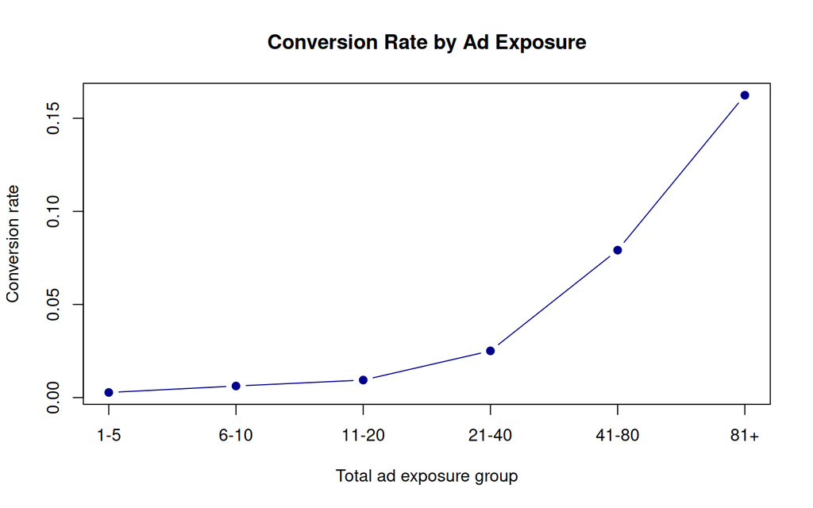

```r
marketing$exposure_group <- cut(
  marketing$`total ads`,
  breaks = c(0, 5, 10, 20, 40, 80, Inf),
  labels = c("1-5", "6-10", "11-20", "21-40", "41-80", "81+")
)

conversion_by_exposure <- aggregate(
  converted ~ exposure_group,
  data = marketing,
  FUN = mean
)

plot(seq_len(nrow(conversion_by_exposure)),
     conversion_by_exposure$converted,
     type = "b", pch = 19, col = "darkblue",
     xaxt = "n",
     main = "Conversion Rate by Ad Exposure",
     xlab = "Total ad exposure group", ylab = "Conversion rate")
axis(1, at = seq_len(nrow(conversion_by_exposure)),
     labels = conversion_by_exposure$exposure_group)
```

## Test group and conversion

```r
group_summary <- aggregate(
  converted ~ `test group`,
  data = marketing,
  FUN = mean
)
names(group_summary)[2] <- "conversion_rate"

print(group_summary)
```

```
##   test group conversion_rate
## 1         ad      0.02572046
## 2        psa      0.01596204
```

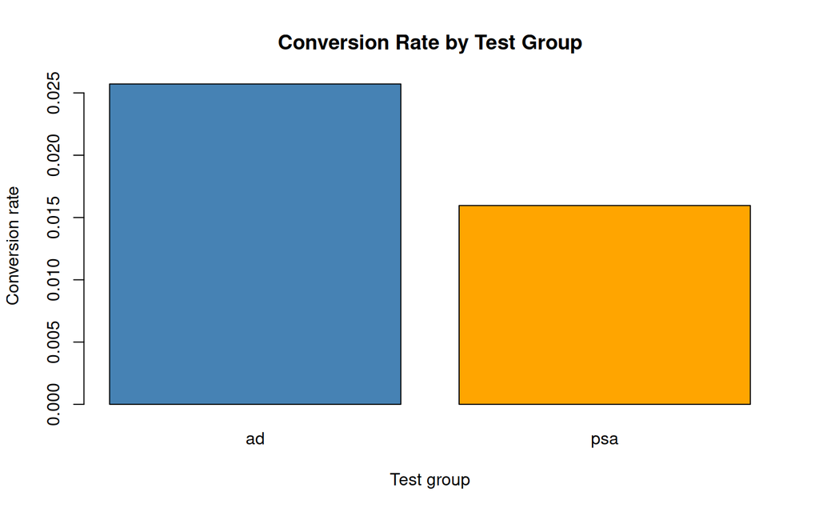

```r
barplot(group_summary$conversion_rate,
        names.arg = group_summary$`test group`,
        col = c("steelblue", "orange"),
        main = "Conversion Rate by Test Group",
        xlab = "Test group", ylab = "Conversion rate")
```

## Conversion patterns by day and hour

```r
day_summary <- aggregate(
  converted ~ `most ads day`, data = marketing, FUN = mean
)
names(day_summary)[2] <- "conversion_rate"
day_summary <- day_summary[order(day_summary$conversion_rate,
                                 decreasing = TRUE), ]
print(day_summary)
```

```
##   most ads day conversion_rate
## 2       Monday      0.03321918
## 6      Tuesday      0.02994625
## 7    Wednesday      0.02612500
## 4       Sunday      0.02543985
## 5     Thursday      0.02179869
## 3     Saturday      0.02092255
## 1       Friday      0.02031115
```

```r
hour_summary <- aggregate(
  converted ~ `most ads hour`, data = marketing, FUN = mean
)
names(hour_summary)[2] <- "conversion_rate"
print(hour_summary)
```

```
##    most ads hour conversion_rate
## 1              0     0.017730496
## 2              1     0.011111111
## 3              2     0.007707129
## 4              3     0.000000000
## 5              4     0.000000000
## 6              5     0.000000000
## 7              6     0.044554455
## 8              7     0.015923567
## 9              8     0.019285309
## 10             9     0.023643024
## 11            10     0.021434039
## 12            11     0.021512247
## 13            12     0.025370888
## 14            13     0.025136154
## 15            14     0.030378038
## 16            15     0.028673038
## 17            16     0.035771920
## 18            17     0.028654124
## 19            18     0.024128686
## 20            19     0.028141361
## 21            20     0.027449618
## 22            21     0.023693606
## 23            22     0.027047054
## 24            23     0.017874876
```

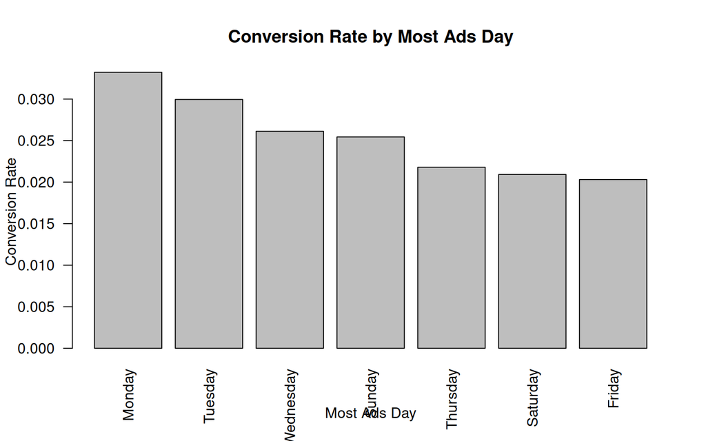

```r
barplot(day_summary$conversion_rate,
        names.arg = day_summary$`most ads day`,
        main = "Conversion Rate by Most Ads Day",
        xlab = "Most Ads Day", ylab = "Conversion Rate", las = 2)
```

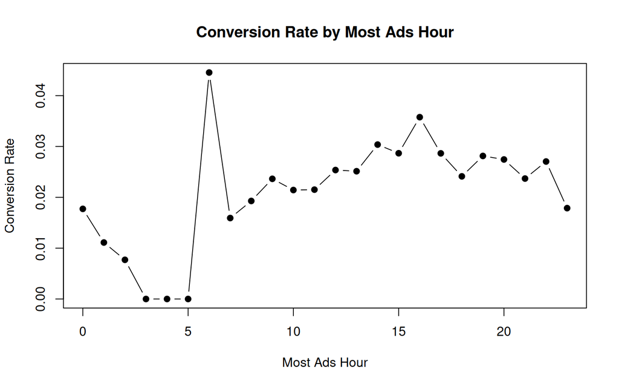

```r
plot(hour_summary$`most ads hour`,
     hour_summary$conversion_rate,
     type = "b", pch = 19,
     main = "Conversion Rate by Most Ads Hour",
     xlab = "Most Ads Hour", ylab = "Conversion Rate")
```

# 4. Comments and observations

- **Distribution of numerical variables:** Total ad exposure is strongly right-skewed. The median user saw 13 ads, while the mean was 24.6 ads. The mean is higher because a small number of users received very large numbers of ads; the maximum was 1391. This suggests that the typical user had modest exposure, but a smaller group remained exposed to the campaign long enough to receive ads repeatedly. The range check shows that the observed `most ads hour` values run from 0 to 23. Peak exposure was most common at hour 13, showing that exposure volume was concentrated around midday.
- **Outliers:** For `total ads`, Q1 is 4, Q3 is 27, and the upper IQR boundary is 61.5. Users with more than 61.5 ads are therefore flagged, producing 5152 outliers. They may represent highly engaged users, users with longer campaign exposure, or repeated targeting; they should not automatically be treated as data errors. The method also flags 564 records for `most ads hour` because its IQR lower bound is 0.5. In this data, the flagged values are hour 0. The range and unique-value checks confirm that hour 0 is an observed timing value, so it should not automatically be treated as invalid or as a data error. It may simply be less common than hours near the center of the distribution. Because `most ads hour` is a time-related, descriptive variable rather than a continuous quantity, its IQR result requires careful interpretation. The main meaningful outlier finding is the high-value tail of `total ads`, which directly measures how many ads users saw.
- **Advertising exposure and conversion:** Converted users saw an average of 83.9 ads and a median of 62, compared with an average of 23 and a median of 12 for users who did not convert. Conversion increased from about 0.27% among users seeing 1-5 ads to 16.24% among those seeing 81 or more. Higher exposure is strongly associated with higher conversion. It does not prove that more ads alone cause conversion because users who stay active longer have more chances both to see ads and to convert.
- **Conversion behavior and test groups:** Only 1490 of 58810 users converted, an overall rate of 2.53%. The `ad` group conversion rate was 2.57%, compared with 1.6% in the PSA/control group. The ad-group rate is about 1.61 times the control rate. This observed difference suggests that the ad treatment performed better than the PSA/control treatment in this sample. Group sizes are very unequal, so rates are more useful than raw conversion counts for this comparison.
- **Timing patterns:** Friday had the most users whose peak exposure occurred on that day, but it did not have the highest conversion rate. Monday had the highest day-level rate at 3.32%, while Friday was lowest at 2.03%. Exposure volume was concentrated around hours 11-15. Hour 16 had a relatively high conversion rate of 3.58% and also had many users. Hour 6 had the highest raw hourly rate, but only 202 users were in that segment, so its rate is less stable. These descriptive differences may reflect audience behavior or campaign scheduling, rather than an effect of timing alone.